# Importing the libraries

```python
import numpy as np
import pandas as pd
import matplotlib.pyplot as plt
import seaborn as sns
```

# Read the CSV file :--

```python
df = pd.read_csv("student-mat.csv")
```

# exploring the dataset characteristics

***Size of the data :--***

```python
df.shape
```

```
(395, 33)
```

***Displays all Columns :--***

```python
df.columns
```

```
Index(['school', 'sex', 'age', 'address', 'famsize', 'Pstatus', 'Medu', 'Fedu',
       'Mjob', 'Fjob', 'reason', 'guardian', 'traveltime', 'studytime',
       'failures', 'schoolsup', 'famsup', 'paid', 'activities', 'nursery',
       'higher', 'internet', 'romantic', 'famrel', 'freetime', 'goout', 'Dalc',
       'Walc', 'health', 'absences', 'G1', 'G2', 'G3'],
      dtype='object')
```

***Information of the datatypes :--***

```python
df.info()
```

```
<class 'pandas.core.frame.DataFrame'>
RangeIndex: 395 entries, 0 to 394
Data columns (total 33 columns):
 #   Column      Non-Null Count  Dtype
---  ------      --------------  -----
 0   school      395 non-null    object
 1   sex         395 non-null    object
 2   age         395 non-null    int64
 3   address     395 non-null    object
 4   famsize     395 non-null    object
 5   Pstatus     395 non-null    object
 6   Medu        395 non-null    int64
 7   Fedu        395 non-null    int64
 8   Mjob        395 non-null    object
 9   Fjob        395 non-null    object
```

[output cut: 25 more lines]

*-^--we noticed that all the data in the csv is of object type and integer type.*

***Statical overview of dataset :--***

```python
df.describe(include='all')
```

|  | school | sex | age | address | famsize | Pstatus | Medu | Fedu | Mjob | Fjob | ... | famrel | freetime | goout | Dalc | Walc | health | absences | G1 | G2 | G3 |
| --- | --- | --- | --- | --- | --- | --- | --- | --- | --- | --- | --- | --- | --- | --- | --- | --- | --- | --- | --- | --- | --- |
| count | 395 | 395 | 395.000000 | 395 | 395 | 395 | 395.000000 | 395.000000 | 395 | 395 | ... | 395.000000 | 395.000000 | 395.000000 | 395.000000 | 395.000000 | 395.000000 | 395.000000 | 395.000000 | 395.000000 | 395.000000 |
| unique | 2 | 2 | NaN | 2 | 2 | 2 | NaN | NaN | 5 | 5 | ... | NaN | NaN | NaN | NaN | NaN | NaN | NaN | NaN | NaN | NaN |
| top | GP | F | NaN | U | GT3 | T | NaN | NaN | other | other | ... | NaN | NaN | NaN | NaN | NaN | NaN | NaN | NaN | NaN | NaN |
| freq | 349 | 208 | NaN | 307 | 281 | 354 | NaN | NaN | 141 | 217 | ... | NaN | NaN | NaN | NaN | NaN | NaN | NaN | NaN | NaN | NaN |
| mean | NaN | NaN | 16.696203 | NaN | NaN | NaN | 2.749367 | 2.521519 | NaN | NaN | ... | 3.944304 | 3.235443 | 3.108861 | 1.481013 | 2.291139 | 3.554430 | 5.708861 | 10.908861 | 10.713924 | 10.415190 |
| std | NaN | NaN | 1.276043 | NaN | NaN | NaN | 1.094735 | 1.088201 | NaN | NaN | ... | 0.896659 | 0.998862 | 1.113278 | 0.890741 | 1.287897 | 1.390303 | 8.003096 | 3.319195 | 3.761505 | 4.581443 |
| min | NaN | NaN | 15.000000 | NaN | NaN | NaN | 0.000000 | 0.000000 | NaN | NaN | ... | 1.000000 | 1.000000 | 1.000000 | 1.000000 | 1.000000 | 1.000000 | 0.000000 | 3.000000 | 0.000000 | 0.000000 |
| 25% | NaN | NaN | 16.000000 | NaN | NaN | NaN | 2.000000 | 2.000000 | NaN | NaN | ... | 4.000000 | 3.000000 | 2.000000 | 1.000000 | 1.000000 | 3.000000 | 0.000000 | 8.000000 | 9.000000 | 8.000000 |
| 50% | NaN | NaN | 17.000000 | NaN | NaN | NaN | 3.000000 | 2.000000 | NaN | NaN | ... | 4.000000 | 3.000000 | 3.000000 | 1.000000 | 2.000000 | 4.000000 | 4.000000 | 11.000000 | 11.000000 | 11.000000 |
| 75% | NaN | NaN | 18.000000 | NaN | NaN | NaN | 4.000000 | 3.000000 | NaN | NaN | ... | 5.000000 | 4.000000 | 4.000000 | 2.000000 | 3.000000 | 5.000000 | 8.000000 | 13.000000 | 13.000000 | 14.000000 |
| max | NaN | NaN | 22.000000 | NaN | NaN | NaN | 4.000000 | 4.000000 | NaN | NaN | ... | 5.000000 | 5.000000 | 5.000000 | 5.000000 | 5.000000 | 5.000000 | 75.000000 | 19.000000 | 19.000000 | 20.000000 |

11 rows × 33 columns

***Top 10 Rows of the dataset :--***

```python
df.head(10)
```

|  | school | sex | age | address | famsize | Pstatus | Medu | Fedu | Mjob | Fjob | ... | famrel | freetime | goout | Dalc | Walc | health | absences | G1 | G2 | G3 |
| --- | --- | --- | --- | --- | --- | --- | --- | --- | --- | --- | --- | --- | --- | --- | --- | --- | --- | --- | --- | --- | --- |
| 0 | GP | F | 18 | U | GT3 | A | 4 | 4 | at_home | teacher | ... | 4 | 3 | 4 | 1 | 1 | 3 | 6 | 5 | 6 | 6 |
| 1 | GP | F | 17 | U | GT3 | T | 1 | 1 | at_home | other | ... | 5 | 3 | 3 | 1 | 1 | 3 | 4 | 5 | 5 | 6 |
| 2 | GP | F | 15 | U | LE3 | T | 1 | 1 | at_home | other | ... | 4 | 3 | 2 | 2 | 3 | 3 | 10 | 7 | 8 | 10 |
| 3 | GP | F | 15 | U | GT3 | T | 4 | 2 | health | services | ... | 3 | 2 | 2 | 1 | 1 | 5 | 2 | 15 | 14 | 15 |
| 4 | GP | F | 16 | U | GT3 | T | 3 | 3 | other | other | ... | 4 | 3 | 2 | 1 | 2 | 5 | 4 | 6 | 10 | 10 |
| 5 | GP | M | 16 | U | LE3 | T | 4 | 3 | services | other | ... | 5 | 4 | 2 | 1 | 2 | 5 | 10 | 15 | 15 | 15 |
| 6 | GP | M | 16 | U | LE3 | T | 2 | 2 | other | other | ... | 4 | 4 | 4 | 1 | 1 | 3 | 0 | 12 | 12 | 11 |
| 7 | GP | F | 17 | U | GT3 | A | 4 | 4 | other | teacher | ... | 4 | 1 | 4 | 1 | 1 | 1 | 6 | 6 | 5 | 6 |
| 8 | GP | M | 15 | U | LE3 | A | 3 | 2 | services | other | ... | 4 | 2 | 2 | 1 | 1 | 1 | 0 | 16 | 18 | 19 |
| 9 | GP | M | 15 | U | GT3 | T | 3 | 4 | other | other | ... | 5 | 5 | 1 | 1 | 1 | 5 | 0 | 14 | 15 | 15 |

10 rows × 33 columns

***10 rows of dataset from bottom :--***

```python
df.tail(10)
```

|  | school | sex | age | address | famsize | Pstatus | Medu | Fedu | Mjob | Fjob | ... | famrel | freetime | goout | Dalc | Walc | health | absences | G1 | G2 | G3 |
| --- | --- | --- | --- | --- | --- | --- | --- | --- | --- | --- | --- | --- | --- | --- | --- | --- | --- | --- | --- | --- | --- |
| 385 | MS | F | 18 | R | GT3 | T | 2 | 2 | at_home | other | ... | 5 | 3 | 3 | 1 | 3 | 4 | 2 | 10 | 9 | 10 |
| 386 | MS | F | 18 | R | GT3 | T | 4 | 4 | teacher | at_home | ... | 4 | 4 | 3 | 2 | 2 | 5 | 7 | 6 | 5 | 6 |
| 387 | MS | F | 19 | R | GT3 | T | 2 | 3 | services | other | ... | 5 | 4 | 2 | 1 | 2 | 5 | 0 | 7 | 5 | 0 |
| 388 | MS | F | 18 | U | LE3 | T | 3 | 1 | teacher | services | ... | 4 | 3 | 4 | 1 | 1 | 1 | 0 | 7 | 9 | 8 |
| 389 | MS | F | 18 | U | GT3 | T | 1 | 1 | other | other | ... | 1 | 1 | 1 | 1 | 1 | 5 | 0 | 6 | 5 | 0 |
| 390 | MS | M | 20 | U | LE3 | A | 2 | 2 | services | services | ... | 5 | 5 | 4 | 4 | 5 | 4 | 11 | 9 | 9 | 9 |
| 391 | MS | M | 17 | U | LE3 | T | 3 | 1 | services | services | ... | 2 | 4 | 5 | 3 | 4 | 2 | 3 | 14 | 16 | 16 |
| 392 | MS | M | 21 | R | GT3 | T | 1 | 1 | other | other | ... | 5 | 5 | 3 | 3 | 3 | 3 | 3 | 10 | 8 | 7 |
| 393 | MS | M | 18 | R | LE3 | T | 3 | 2 | services | other | ... | 4 | 4 | 1 | 3 | 4 | 5 | 0 | 11 | 12 | 10 |
| 394 | MS | M | 19 | U | LE3 | T | 1 | 1 | other | at_home | ... | 3 | 2 | 3 | 3 | 3 | 5 | 5 | 8 | 9 | 9 |

10 rows × 33 columns

# hence we need to fix it lets now exploring duplicates and each column to find any other anomalies

**When Duplicate values is present return 'True' , Otherwise 'False' --**

```python
df.duplicated()
```

```
0      False
1      False
2      False
3      False
4      False
       ...
390    False
391    False
392    False
393    False
394    False
Length: 395, dtype: bool
```

```python
#Count the missing values in 'humidity' column
pd.isnull(df['school']).value_counts()
```

```
school
False    395
Name: count, dtype: int64
```

***^-^---Here we can see that no any duplicates values are present in the dataset.***

```python
df['school'].unique()
```

```
array(['GP', 'MS'], dtype=object)
```

**Here we can see that "school" has only two type of object dada that is "GP" and "MS".**

```python
df['famsize'].unique()
```

```
array(['GT3', 'LE3'], dtype=object)
```

```python
df['address'].unique()
```

```
array(['U', 'R'], dtype=object)
```

**Here we can see that "address" has only two type of object dada that is "U" for urban and "R" for Rural.**

```python
df['Pstatus'].unique()
```

```
array(['A', 'T'], dtype=object)
```

**Here we can see that "Pstatus" has only two type of object dada that is "A" and "T".**

```python
df['Mjob'].unique()
```

```
array(['at_home', 'health', 'other', 'services', 'teacher'], dtype=object)
```

**Here we can see that "Mjob" is basically students Mother job like "at_home", "health", "other", "service" and "teacher" those are object dada type.**

```python
df['Fjob'].unique()
```

```
array(['teacher', 'other', 'services', 'health', 'at_home'], dtype=object)
```

**Here we can see that "Fjob" is basically students Father job like "at_home", "health", "other", "service" and "teacher" those are object dada type.**

# Add legal_drinker total_grades columns :--

```python
def majority(x):
    if x > 21:
        return True
    else:
        return False

df['legal_drinker'] = df['age'].apply(majority)
df.head(10)
```

|  | school | sex | age | address | famsize | Pstatus | Medu | Fedu | Mjob | Fjob | ... | freetime | goout | Dalc | Walc | health | absences | G1 | G2 | G3 | legal_drinker |
| --- | --- | --- | --- | --- | --- | --- | --- | --- | --- | --- | --- | --- | --- | --- | --- | --- | --- | --- | --- | --- | --- |
| 0 | GP | F | 18 | U | GT3 | A | 4 | 4 | at_home | teacher | ... | 3 | 4 | 1 | 1 | 3 | 6 | 5 | 6 | 6 | False |
| 1 | GP | F | 17 | U | GT3 | T | 1 | 1 | at_home | other | ... | 3 | 3 | 1 | 1 | 3 | 4 | 5 | 5 | 6 | False |
| 2 | GP | F | 15 | U | LE3 | T | 1 | 1 | at_home | other | ... | 3 | 2 | 2 | 3 | 3 | 10 | 7 | 8 | 10 | False |
| 3 | GP | F | 15 | U | GT3 | T | 4 | 2 | health | services | ... | 2 | 2 | 1 | 1 | 5 | 2 | 15 | 14 | 15 | False |
| 4 | GP | F | 16 | U | GT3 | T | 3 | 3 | other | other | ... | 3 | 2 | 1 | 2 | 5 | 4 | 6 | 10 | 10 | False |
| 5 | GP | M | 16 | U | LE3 | T | 4 | 3 | services | other | ... | 4 | 2 | 1 | 2 | 5 | 10 | 15 | 15 | 15 | False |
| 6 | GP | M | 16 | U | LE3 | T | 2 | 2 | other | other | ... | 4 | 4 | 1 | 1 | 3 | 0 | 12 | 12 | 11 | False |
| 7 | GP | F | 17 | U | GT3 | A | 4 | 4 | other | teacher | ... | 1 | 4 | 1 | 1 | 1 | 6 | 6 | 5 | 6 | False |
| 8 | GP | M | 15 | U | LE3 | A | 3 | 2 | services | other | ... | 2 | 2 | 1 | 1 | 1 | 0 | 16 | 18 | 19 | False |
| 9 | GP | M | 15 | U | GT3 | T | 3 | 4 | other | other | ... | 5 | 1 | 1 | 1 | 5 | 0 | 14 | 15 | 15 | False |

10 rows × 34 columns

**We can check the "legel drinker" student's whose age is greater than 21 years decided by the government and it can be added as extra column in this dataset to find "legel drinker".**

# Correlation Analysis :--

```python
df.corr(numeric_only=True)
```

|  | age | Medu | Fedu | traveltime | studytime | failures | famrel | freetime | goout | Dalc | Walc | health | absences | G1 | G2 | G3 | legal_drinker |
| --- | --- | --- | --- | --- | --- | --- | --- | --- | --- | --- | --- | --- | --- | --- | --- | --- | --- |
| age | 1.000000 | -0.163658 | -0.163438 | 0.070641 | -0.004140 | 0.243665 | 0.053940 | 0.016434 | 0.126964 | 0.131125 | 0.117276 | -0.062187 | 0.175230 | -0.064081 | -0.143474 | -0.161579 | 0.209664 |
| Medu | -0.163658 | 1.000000 | 0.623455 | -0.171639 | 0.064944 | -0.236680 | -0.003914 | 0.030891 | 0.064094 | 0.019834 | -0.047123 | -0.046878 | 0.100285 | 0.205341 | 0.215527 | 0.217147 | 0.011549 |
| Fedu | -0.163438 | 0.623455 | 1.000000 | -0.158194 | -0.009175 | -0.250408 | -0.001370 | -0.012846 | 0.043105 | 0.002386 | -0.012631 | 0.014742 | 0.024473 | 0.190270 | 0.164893 | 0.152457 | -0.070529 |
| traveltime | 0.070641 | -0.171639 | -0.158194 | 1.000000 | -0.100909 | 0.092239 | -0.016808 | -0.017025 | 0.028540 | 0.138325 | 0.134116 | 0.007501 | -0.012944 | -0.093040 | -0.153198 | -0.117142 | -0.032406 |
| studytime | -0.004140 | 0.064944 | -0.009175 | -0.100909 | 1.000000 | -0.173563 | 0.039731 | -0.143198 | -0.063904 | -0.196019 | -0.253785 | -0.075616 | -0.062700 | 0.160612 | 0.135880 | 0.097820 | -0.062236 |
| failures | 0.243665 | -0.236680 | -0.250408 | 0.092239 | -0.173563 | 1.000000 | -0.044337 | 0.091987 | 0.124561 | 0.136047 | 0.141962 | 0.065827 | 0.063726 | -0.354718 | -0.355896 | -0.360415 | 0.180827 |
| famrel | 0.053940 | -0.003914 | -0.001370 | -0.016808 | 0.039731 | -0.044337 | 1.000000 | 0.150701 | 0.064568 | -0.077594 | -0.113397 | 0.094056 | -0.044354 | 0.022168 | -0.018281 | 0.051363 | 0.059390 |
| freetime | 0.016434 | 0.030891 | -0.012846 | -0.017025 | -0.143198 | 0.091987 | 0.150701 | 1.000000 | 0.285019 | 0.209001 | 0.147822 | 0.075733 | -0.058078 | 0.012613 | -0.013777 | 0.011307 | 0.038611 |
| goout | 0.126964 | 0.064094 | 0.043105 | 0.028540 | -0.063904 | 0.124561 | 0.064568 | 0.285019 | 1.000000 | 0.266994 | 0.420386 | -0.009577 | 0.044302 | -0.149104 | -0.162250 | -0.132791 | 0.085688 |
| Dalc | 0.131125 | 0.019834 | 0.002386 | 0.138325 | -0.196019 | 0.136047 | -0.077594 | 0.209001 | 0.266994 | 1.000000 | 0.647544 | 0.077180 | 0.111908 | -0.094159 | -0.064120 | -0.054660 | 0.199282 |
| Walc | 0.117276 | -0.047123 | -0.012631 | 0.134116 | -0.253785 | 0.141962 | -0.113397 | 0.147822 | 0.420386 | 0.647544 | 1.000000 | 0.092476 | 0.136291 | -0.126179 | -0.084927 | -0.051939 | 0.106098 |
| health | -0.062187 | -0.046878 | 0.014742 | 0.007501 | -0.075616 | 0.065827 | 0.094056 | 0.075733 | -0.009577 | 0.077180 | 0.092476 | 1.000000 | -0.029937 | -0.073172 | -0.097720 | -0.061335 | -0.092680 |
| absences | 0.175230 | 0.100285 | 0.024473 | -0.012944 | -0.062700 | 0.063726 | -0.044354 | -0.058078 | 0.044302 | 0.111908 | 0.136291 | -0.029937 | 1.000000 | -0.031003 | -0.031777 | 0.034247 | 0.064865 |
| G1 | -0.064081 | 0.205341 | 0.190270 | -0.093040 | 0.160612 | -0.354718 | 0.022168 | 0.012613 | -0.149104 | -0.094159 | -0.126179 | -0.073172 | -0.031003 | 1.000000 | 0.852118 | 0.801468 | -0.074602 |
| G2 | -0.143474 | 0.215527 | 0.164893 | -0.153198 | 0.135880 | -0.355896 | -0.018281 | -0.013777 | -0.162250 | -0.064120 | -0.084927 | -0.097720 | -0.031777 | 0.852118 | 1.000000 | 0.904868 | -0.036395 |
| G3 | -0.161579 | 0.217147 | 0.152457 | -0.117142 | 0.097820 | -0.360415 | 0.051363 | 0.011307 | -0.132791 | -0.054660 | -0.051939 | -0.061335 | 0.034247 | 0.801468 | 0.904868 | 1.000000 | -0.026592 |
| legal_drinker | 0.209664 | 0.011549 | -0.070529 | -0.032406 | -0.062236 | 0.180827 | 0.059390 | 0.038611 | 0.085688 | 0.199282 | 0.106098 | -0.092680 | 0.064865 | -0.074602 | -0.036395 | -0.026592 | 1.000000 |

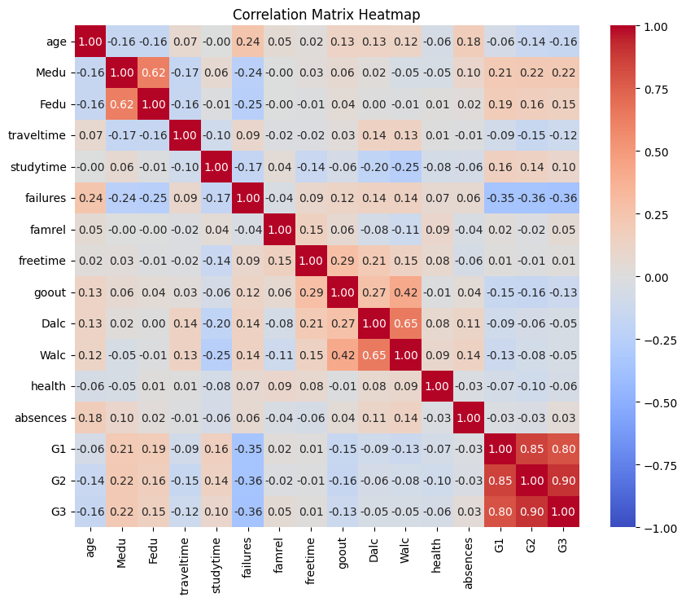

```python
num_df = df.select_dtypes('number')
correlation_matrix = num_df.corr()
plt.figure(figsize=(10, 8))
sns.heatmap(correlation_matrix, annot=True, cmap='coolwarm', fmt='.2f', vmin=-1, vmax=1)
plt.title("Correlation Matrix Heatmap")
plt.show()
```

***Univariate Graphical Analysis on the basis of School :--***

```
there are 349 student in GP school and 46 student in MS school
```

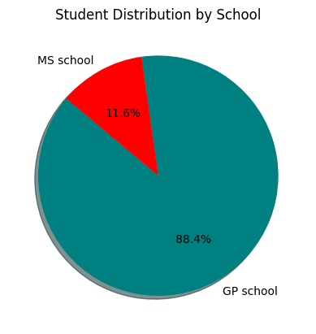

```python
school_counts = df.school.value_counts()
plt.pie(x= school_counts,labels=["GP school", "MS school"], shadow=True, colors=["teal", "red"],autopct="%1.1f%%", startangle=140)
plt.title("Student Distribution by School")
print(f"there are {school_counts.iloc[0]} student in GP school and {school_counts.iloc[1]} student in MS school")
```

***Univariate Graphical Analysis on the basis of Gender :--***

```
there are 208 female and 187 male in math course
```

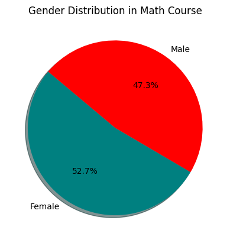

```python
sex_counts = df.sex.value_counts()
plt.pie(x= sex_counts,labels=["Female", "Male"], shadow=True, colors=["teal", "red"],autopct="%1.1f%%", startangle=140)
plt.title("Gender Distribution in Math Course")
print(f"there are {sex_counts.iloc[0]} female and {sex_counts.iloc[1]} male in math course")
```

***Univariate Graphical Analysis on the basis of Age :--***

```
age
16    104
17     98
18     82
15     82
19     24
20      3
22      1
21      1
Name: count, dtype: int64
```

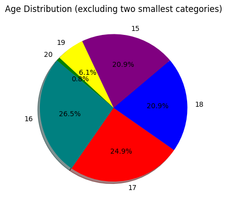

```python
ages_count = df.age.value_counts()
plt.pie(x=ages_count.iloc[:-2], labels=ages_count.index[:-2], shadow=True,
        colors=["teal", "red", "blue", "purple", "yellow", "green", "black", "#888888"],autopct="%1.1f%%", startangle=140)
plt.title("Age Distribution (excluding two smallest categories)")
ages_count
```

***Mother Education :--***

```python
def set_edu_name(x):
    if x == 0:
        return "none education"
    if x == 1:
        return "primary education"
    if x == 2:
        return "5th to 9th"
    if x == 3:
        return "secondary education"
    if x == 4:
        return "higher education"
    return x

df.Medu = df.Medu.apply(set_edu_name)
df.Fedu = df.Fedu.apply(set_edu_name)
Mother_education = df.Medu.value_counts()
print(Mother_education)
```

```
Medu
higher education       131
5th to 9th             103
secondary education     99
primary education       59
none education           3
Name: count, dtype: int64
```

```
Medu
higher education       131
5th to 9th             103
secondary education     99
primary education       59
none education           3
Name: count, dtype: int64
It seems that 60% of women have secondary or university education.
```

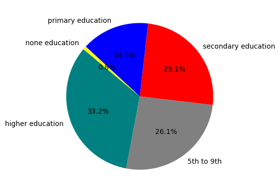

```python
Mother_education = df.Medu.value_counts()
print(Mother_education)
print('It seems that 60% of women have secondary or university education.')
plt.pie(x=Mother_education, labels=Mother_education.index, autopct="%1.1f%%", startangle=140 ,colors=["teal", "gray", "red", "blue", "yellow"])
plt.show()
```

***Father Education :--***

```
Fedu
5th to 9th             115
secondary education    100
higher education        96
primary education       82
none education           2
Name: count, dtype: int64
```

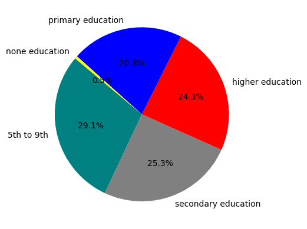

```python
father_education = df.Fedu.value_counts()
print(father_education)
plt.pie(x=father_education, labels=father_education.index, autopct="%1.1f%%", startangle=140 ,colors=["teal", "gray", "red", "blue", "yellow"])
plt.show()
```

# Comparison between students Mothers education and Father education

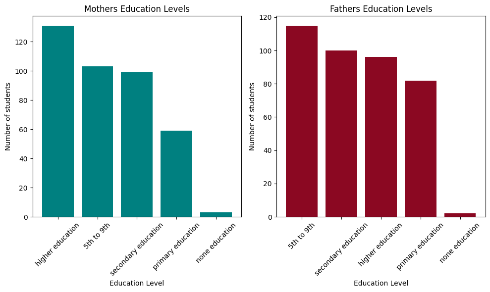

```python
plt.figure(figsize=(10,6))

plt.subplot(1, 2, 1)
plt.bar(Mother_education.index, Mother_education, color="teal")
plt.title('Mothers Education Levels')
plt.xlabel('Education Level')
plt.ylabel('Number of students')
plt.xticks(rotation=45)

plt.subplot(1, 2, 2)
plt.bar(father_education.index, father_education, color="#8B0822")
plt.title('Fathers Education Levels')
plt.xlabel('Education Level')
plt.ylabel('Number of students')
plt.xticks(rotation=45)

plt.tight_layout()
plt.show()
```

# Student's Mother job status :--

```python
mother_job = df.Mjob.value_counts()
print(mother_job)
print("It seem Some mothers are stay-at-home, meaning they don't have an external job and are likely focused on home responsibilities.")
```

```
Mjob
other       141
services    103
at_home      59
teacher      58
health       34
Name: count, dtype: int64
It seem Some mothers are stay-at-home, meaning they don't have an external job and are likely focused on home responsibilities.
```

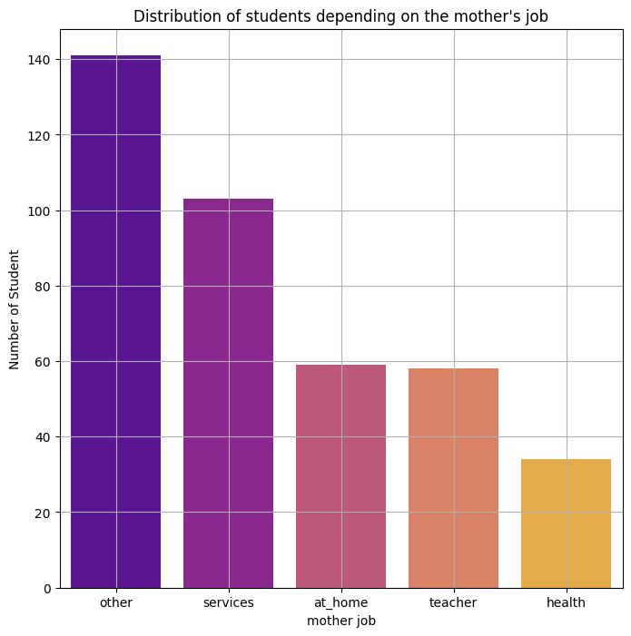

```python
plt.figure(figsize=(8,8))
sns.barplot(x=mother_job.index, y=mother_job, palette='plasma')
plt.title("Distribution of students depending on the mother's job")
plt.xlabel("mother job")
plt.ylabel("Number of Student")
plt.grid()
plt.show()
```

**Here we can see that majority(141) of students mother other type of job preferred and service 103 , at_home 59, techer 58 and health department 34 mothers are worked.**

# Student's Father job status :--

```python
father_job = df.Fjob.value_counts()
print(father_job)
print("The distribution suggests that fathers have jobs in a variety of sectors.")
```

```
Fjob
other       217
services    111
teacher      29
at_home      20
health       18
Name: count, dtype: int64
The distribution suggests that fathers have jobs in a variety of sectors.
```

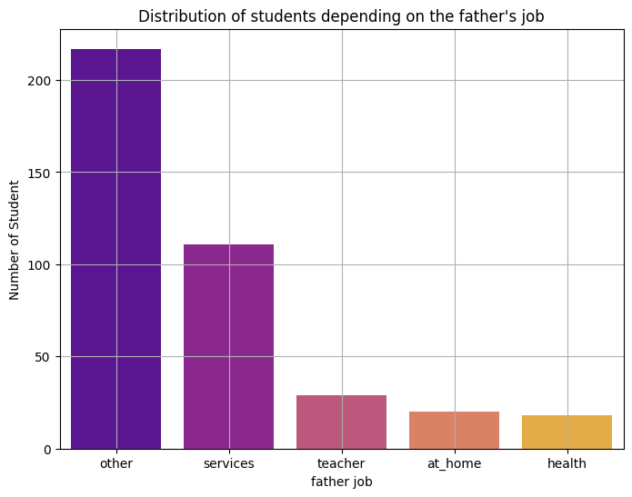

```python
plt.figure(figsize=(8,6))
sns.barplot(x=father_job.index, y=father_job, palette='plasma')
plt.title("Distribution of students depending on the father's job")
plt.xlabel("father job")
plt.ylabel("Number of Student")
plt.grid()
plt.show()
```

**Here we can see that majority(217) of students father other type of work proffession choosen and service 111, teacher 29, at_home 20 and in health sector 18 father are worked.**

# Workdays alcohol consumption :--

```
Dalc
1    276
2     75
3     26
5      9
4      9
Name: count, dtype: int64
This means that students' Daily alcohol consumption is between medium and low.
```

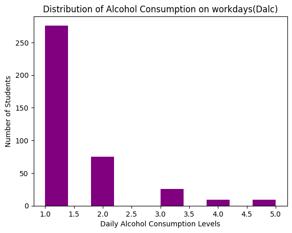

```python
# Count the frequency of each alcohol consumption level on workdays
# and plot a histogram to visualize the distribution
workdays_alc_consumption = df.Dalc.value_counts()
df.Dalc.plot(kind="hist", title="Distribution of Alcohol Consumption on workdays(Dalc)", color="purple")
print(workdays_alc_consumption)
plt.xlabel("Daily Alcohol Consumption Levels")
plt.ylabel("Number of Students")
print("This means that students' Daily alcohol consumption is between medium and low.")
```

**After executing this code, the output will include a histogram that visually represents the distribution of students' daily alcohol consumption on workdays. The printed frequencies will show how many students fall into each level of consumption. The analysis suggests that the majority of students tend to have medium to low levels of daily alcohol consumption on workdays.**

# Weekend Alcohol Consumptoin :--

```
Walc
1    151
2     85
3     80
4     51
5     28
Name: count, dtype: int64
This means that students' weekly alcohol consumption is between medium and low.
```

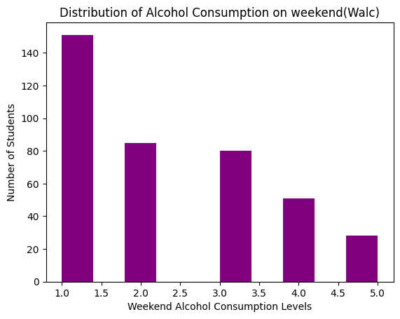

```python
# Count the frequency of each alcohol consumption level on weekend
# and plot a histogram to visualize the distribution
weekend_alc_consumptioni = df.Walc.value_counts()
df.Walc.plot(kind="hist", title="Distribution of Alcohol Consumption on weekend(Walc)", color="purple")
print(weekend_alc_consumptioni)
plt.xlabel("Weekend Alcohol Consumption Levels")
plt.ylabel("Number of Students")
print("This means that students' weekly alcohol consumption is between medium and low.")
```

**After executing this code, a histogram will be displayed showing the distribution of students' alcohol consumption on weekends. The `value_counts()` output reveals the frequency of each consumption level. The analysis indicates that students' alcohol consumption on weekends predominantly falls between medium and low levels.**

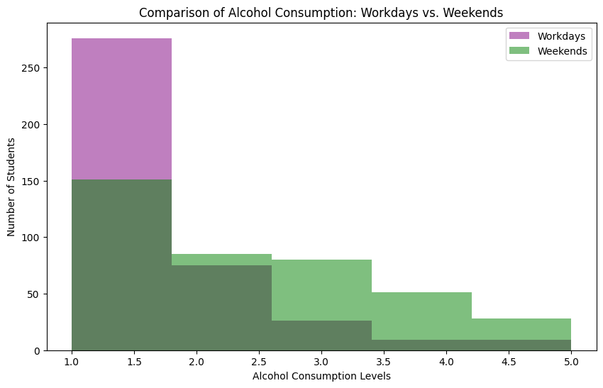

```python
import matplotlib.pyplot as plt

# Create a combined histogram for workdays and weekends alcohol consumption
plt.figure(figsize=(10, 6))

# Plot histogram for alcohol consumption on workdays
df.Dalc.plot(kind="hist", alpha=0.5, bins=5, label='Workdays', color='purple')

# Plot histogram for alcohol consumption on weekends
df.Walc.plot(kind="hist", alpha=0.5, bins=5, label='Weekends', color='green')

# Add labels and title
plt.xlabel("Alcohol Consumption Levels")
plt.ylabel("Number of Students")
plt.title("Comparison of Alcohol Consumption: Workdays vs. Weekends")
plt.legend()

# Show the plot
plt.show()
```

**This code creates a single histogram to visualize and compare the distribution of students' alcohol consumption on workdays versus weekends. It plots the consumption data for both periods on the same graph using different colors—purple for workdays and green for weekends—with semi-transparency to highlight overlapping areas. The x-axis indicates alcohol consumption levels, and the y-axis shows the number of students in each consumption category. The histogram allows for an effective comparison of drinking patterns across the two time periods.**

# Backlog_Paper as Failures in previous semester :--

```python
failures = df.failures.value_counts()
print(f"Number of students who have no backlog in previous semesters is {failures.iloc[0]} and there are no any student whose backlog more than 3 papers")
failures
```

```
Number of students who have no backlog in previous semesters is 312 and there are no any student whose backlog more than 3 papers
```

```
failures
0    312
1     50
2     17
3     16
Name: count, dtype: int64
```

**It calculates the count of students with varying numbers of failures, then prints the number of students with no backlogs (the first value in the failures Series). The output also confirms that there are no students with more than three backlogs. This information helps understand the academic performance of students regarding their past failures.**

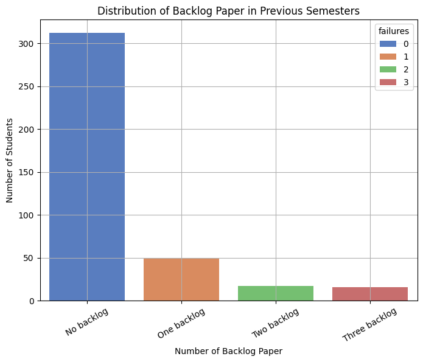

```python
#Creating the bar plot for checking Backlog with number of students
plt.figure(figsize=(8, 6))
ax = sns.barplot(x=failures.index, y= failures.values, hue=failures.index, palette='muted')
plt.title("Distribution of Backlog Paper in Previous Semesters")
plt.xlabel("Number of Backlog Paper")
plt.ylabel("Number of Students")
ax.set_xticks(range(len(failures.index)))
ax.set_xticklabels(["No backlog", "One backlog", "Two backlog", "Three backlog"], rotation=30)
plt.grid(True)
plt.show()
```

**The plot displays the number of students with each backlog category, from "No backlog" to "Three backlogs," with distinct colors for clarity. The x-axis represents the number of backlog papers, while the y-axis shows the number of students in each category. The plot includes grid lines for better readability and labels with a 30-degree rotation for easier interpretation. This visualization helps in understanding the distribution of academic backlogs among students.**

# Extra Educational support for some students from school :--

```python
#Educational support
schoolup = df.schoolsup.value_counts()
print(f"({schoolup.max()}) students have without extra support from school")
schoolup
```

```
(344) students have without extra support from school
```

```
schoolsup
no     344
yes     51
Name: count, dtype: int64
```

**Here distribution of students receiving educational support from their school. It determines the number of students who do not receive extra support, highlighting the maximum count in the dataset. The output provides insight into the level of educational support available to students.**

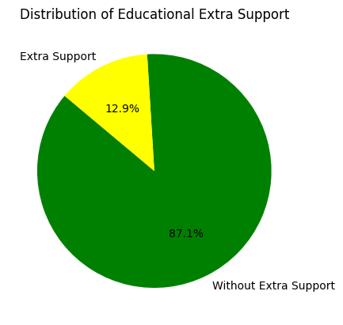

```python
plt.pie(x=schoolup, labels=[ "Without Extra Support", "Extra Support"], autopct='%1.1f%%', colors=["green", "yellow"], startangle=140)
plt.title("Distribution of Educational Extra Support")
plt.show()
```

# Students extra family support :--

```python
familySupport = df.famsup.value_counts()
print(f"No of students({familySupport.loc['no']}) who have no extra family support.")
familySupport
```

```
No of students(153) who have no extra family support.
```

```
famsup
yes    242
no     153
Name: count, dtype: int64
```

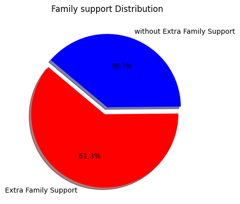

```python
plt.pie(x=familySupport, labels=["Extra Family Support", "without Extra Family Support"],
        autopct="%1.1f%%", startangle=140, colors=["red", "blue"], shadow=True, explode=[0.1, 0])
plt.title("Family support Distribution")
plt.show()
```

**here we can analyzes and visualizes the distribution of students with and without extra family support. It prints the number of students who do not receive extra family support and creates a pie chart to illustrate the proportion of students with and without such support. The chart uses distinct colors and a shadow effect for better visualization and includes percentage labels for clarity.**

# Nursery :--

```python
nursery = df.nursery.value_counts()
print(f"Sum students({nursery.loc['no']}) have not attended nursery in childhood age.")
nursery
```

```
Sum students(81) have not attended nursery in childhood age.
```

```
nursery
yes    314
no      81
Name: count, dtype: int64
```

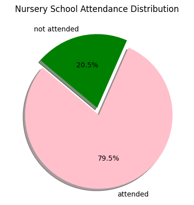

```python
plt.pie(x=nursery, labels=["attended", "not attended"], autopct="%1.1f%%", startangle=140, colors=["pink", "green"], shadow=True, explode=[0.1, 0])
plt.title("Nursery School Attendance Distribution")
plt.show()
```

**Here we can visualizes the distribution of students who attended nursery school versus those who did not. It prints the number of students who did not attend nursery and generates a pie chart to show the proportions of attendees and non-attendees. The chart uses distinct colors and includes percentage labels to clearly convey the distribution of nursery school attendance.**

# Higher Education :--

```
higher
yes    375
no      20
Name: count, dtype: int64

The Most Student(94.9%) Want a Higher Education.
```

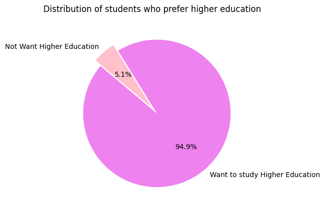

```python
preferHigherEducation = df.higher.value_counts()
print(preferHigherEducation, '\n')
print(f"The Most Student({round(preferHigherEducation.iloc[0] / len(df.higher) * 100, 1)}%) Want a Higher Education.")
plt.pie(x=preferHigherEducation, labels=["Want to study Higher Education", "Not Want Higher Education"],
        autopct="%1.1f%%", startangle=140, colors=["violet", "pink"],  explode=[0.1, 0])
plt.title("Distribution of students who prefer higher education")
plt.show()
```

**Here we can visualizes students' preferences for higher education. It prints the distribution of students who want higher education and calculates the percentage of those students relative to the total. A pie chart is generated to illustrate the proportion of students who prefer higher education versus those who do not, using distinct colors and percentage labels for clarity.**

# Internet Acess :--

```
internet
yes    329
no      66
Name: count, dtype: int64
```

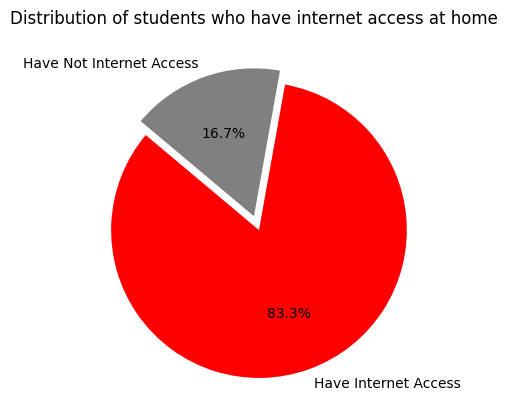

```
The Most Student(83.3%) have internet access at home.
```

```python
internetAccess = df.internet.value_counts()
print(internetAccess)
plt.pie(x=internetAccess, labels=["Have Internet Access", "Have Not Internet Access"],
        autopct="%1.1f%%", startangle=140, colors=["red", "gray"],  explode=[0.1, 0])
plt.title("Distribution of students who have internet access at home")
plt.show()
print(f"The Most Student({round(internetAccess.loc['yes'] / len(df.internet) * 100, 1)}%) have internet access at home.")
```

**Here we can see the distribution of students with and without internet access at home. It prints the count of students with and without internet access and generates a pie chart to illustrate the proportions, using distinct colors and percentage labels. The output also indicates that the majority of students have internet access at home.**

# Romantic Relationship :--

```
romantic
no     263
yes    132
Name: count, dtype: int64
```

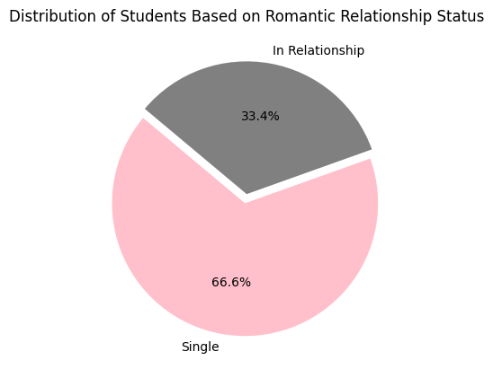

```python
df.romantic.value_counts()
in_relationship = df.romantic.value_counts()
print(in_relationship)
plt.pie(x=in_relationship, labels=["Single", "In Relationship"],
        autopct="%1.1f%%", startangle=140, colors=["pink", "gray"],  explode=[0.07, 0])
plt.title("Distribution of Students Based on Romantic Relationship Status")
plt.show()
```

**Here we can see that the distribution of students based on their romantic relationship status. It prints the count of students who are single versus those in a relationship and creates a pie chart to display the proportions. The chart uses different colors and percentage labels to clearly convey the distribution of relationship status among students.**

# Absence :--

```python
df.absences.value_counts().to_frame().head(10)
```

| absences | count |
| --- | --- |
| 0 | 115 |
| 2 | 65 |
| 4 | 53 |
| 6 | 31 |
| 8 | 22 |
| 10 | 17 |
| 14 | 12 |
| 12 | 12 |
| 3 | 8 |
| 7 | 7 |

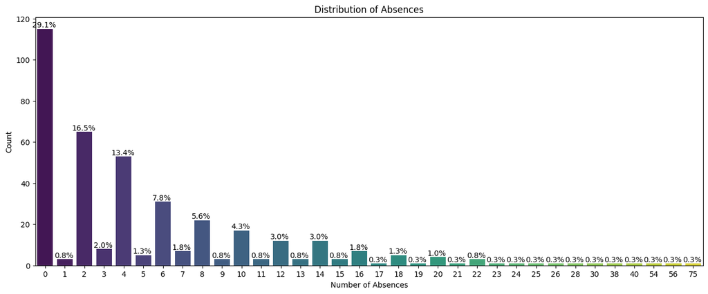

```python
plt.figure(figsize=(16, 6))
ax = sns.countplot(x='absences', data=df, palette="viridis")
plt.title('Distribution of Absences')
plt.xlabel('Number of Absences')
plt.ylabel('Count')
plt.xticks(rotation=0)

total = len(df['absences']) # 395
for p in ax.patches:
    percentage = '{:.1f}%'.format(100 * p.get_height() / total)
    x = p.get_x() + p.get_width() / 2 - 0.05
    y = p.get_height()
    ax.annotate(percentage, (x, y), ha='center', va='bottom')

plt.show()
```

**Here we can see that the distribution of student absences using a count plot. It creates a bar plot where the x-axis represents the number of absences and the y-axis shows the count of students for each absence category. Additionally, it annotates each bar with the percentage of the total absences to provide a clearer understanding of the distribution. The plot uses the "viridis" color palette for a visually appealing representation.**

# Grade1 (G1)

```python
df.G1.value_counts().to_frame()
```

| G1 | count |
| --- | --- |
| 10 | 51 |
| 8 | 41 |
| 11 | 39 |
| 7 | 37 |
| 12 | 35 |
| 13 | 33 |
| 9 | 31 |
| 14 | 30 |
| 15 | 24 |
| 6 | 24 |
| 16 | 22 |
| 18 | 8 |
| 17 | 8 |
| 5 | 7 |
| 19 | 3 |
| 4 | 1 |
| 3 | 1 |

```python
print(f"The mean of Grade 1 is {df.G1.mean()}")

G1_more_15 = df["G1"][df.G1 > 15].count()
percent_G1 = round(G1_more_15/df.G1.count() * 100, 1)
print(f"Number of student who got a grade1 more than 15 is {G1_more_15} which is {percent_G1}%.")
```

```
The mean of Grade 1 is 10.90886075949367
Number of student who got a grade1 more than 15 is 41 which is 10.4%.
```

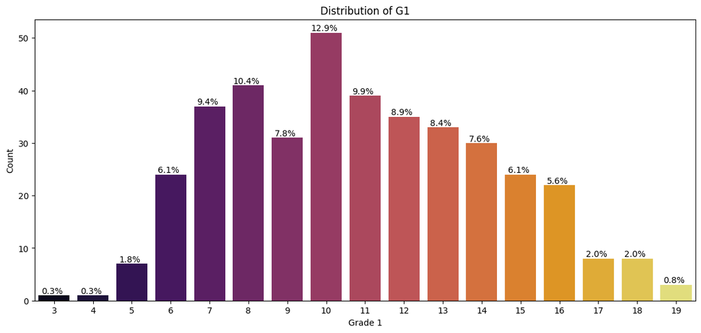

```python
plt.figure(figsize=(14, 6))
ax = sns.countplot(x='G1', data=df, palette="inferno")
plt.title('Distribution of G1')
plt.xlabel('Grade 1')
plt.ylabel('Count')
plt.xticks(rotation=0)

total = len(df['G1']) # 395
for p in ax.patches:
    percentage = '{:.1f}%'.format(100 * p.get_height() / total)
    x = p.get_x() + p.get_width() / 2 - 0.05
    y = p.get_height()
    ax.annotate(percentage, (x, y), ha='center', va='bottom')

plt.show()
```

**This code provides insights into the distribution of students' Grade 1 (G1) scores. It first calculates and prints the mean of G1 scores and identifies the number and percentage of students who scored more than 15. A count plot is then generated to visualize the distribution of G1 scores, with bars representing the count of students for each grade level. Each bar is annotated with the percentage of the total, and the plot uses the "inferno" color palette for enhanced visual appeal.**

# Grade2 (G2) :--

```python
df.G2.value_counts().to_frame()
```

| G2 | count |
| --- | --- |
| 9 | 50 |
| 10 | 46 |
| 12 | 41 |
| 13 | 37 |
| 11 | 35 |
| 15 | 34 |
| 8 | 32 |
| 14 | 23 |
| 7 | 21 |
| 5 | 15 |
| 6 | 14 |
| 0 | 13 |
| 16 | 13 |
| 18 | 12 |
| 17 | 5 |
| 19 | 3 |
| 4 | 1 |

```python
print(f"The mean of Grade 2 is {df.G2.mean()}")

G2_more_15 = df["G2"][df.G2 > 15].count()
percent_G2= round(G2_more_15/df.G2.count() * 100, 1)
print(f"Number of student who got a grade2 more than 15 is {G2_more_15} which is {percent_G2}%.")
```

```
The mean of Grade 2 is 10.713924050632912
Number of student who got a grade2 more than 15 is 33 which is 8.4%.
```

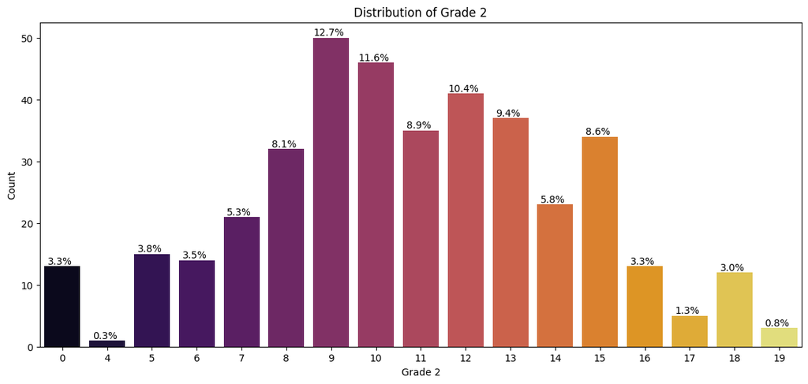

```python
plt.figure(figsize=(14, 6))
ax = sns.countplot(x='G2', data=df, palette="inferno")
plt.title('Distribution of Grade 2')
plt.xlabel('Grade 2')
plt.ylabel('Count')
plt.xticks(rotation=0)

total = len(df['G2']) # 395
for p in ax.patches:
    percentage = '{:.1f}%'.format(100 * p.get_height() / total)
    x = p.get_x() + p.get_width() / 2 - 0.05
    y = p.get_height()
    ax.annotate(percentage, (x, y), ha='center', va='bottom')

plt.show()
```

**In this section of code provides a comprehensive analysis of Grade 2 (G2) scores for students. It starts by calculating and printing the mean G2 score across the dataset. Then, it identifies the number and percentage of students who received a G2 score higher than 15, highlighting the proportion of high performers.** **Following the numerical analysis, the code generates a count plot to visualize the distribution of G2 scores. The plot displays the frequency of each grade level, with bars colored using the "inferno" palette. Each bar is annotated with the percentage of the total count, offering a clear view of how G2 scores are distributed among students. This visualization helps in understanding the spread and concentration of grades within the dataset.**

# Grade3 (G3)

```python
df.G3.value_counts().to_frame()
```

| G3 | count |
| --- | --- |
| 10 | 56 |
| 11 | 47 |
| 0 | 38 |
| 15 | 33 |
| 8 | 32 |
| 12 | 31 |
| 13 | 31 |
| 9 | 28 |
| 14 | 27 |
| 16 | 16 |
| 6 | 15 |
| 18 | 12 |
| 7 | 9 |
| 5 | 7 |
| 17 | 6 |
| 19 | 5 |
| 20 | 1 |
| 4 | 1 |

```python
print(f"The mean of Grade 3 is {df.G3.mean()}")

G3_more_15 = df["G3"][df.G3 > 15].count()
percent_G3 = round(G3_more_15/df.G3.count() * 100, 1)
print(f"Number of student who got a grade3 more than 15 is {G3_more_15} which is {percent_G3}%.")
```

```
The mean of Grade 3 is 10.415189873417722
Number of student who got a grade3 more than 15 is 40 which is 10.1%.
```

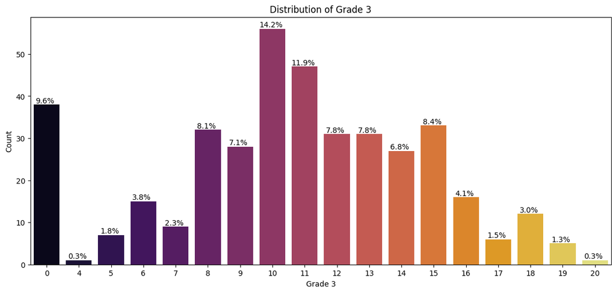

```python
plt.figure(figsize=(14, 6))
ax = sns.countplot(x='G3', data=df, palette="inferno")
plt.title('Distribution of Grade 3')
plt.xlabel('Grade 3')
plt.ylabel('Count')
plt.xticks(rotation=0)

total = len(df['G3']) # 395
for p in ax.patches:
    percentage = '{:.1f}%'.format(100 * p.get_height() / total)
    x = p.get_x() + p.get_width() / 2 - 0.05
    y = p.get_height()
    ax.annotate(percentage, (x, y), ha='center', va='bottom')

plt.show()
```

**Here we can see that Grade3 (G3) scores among students. It begins by calculating and printing the mean G3 score for the dataset. The code then identifies the number and percentage of students who achieved a G3 score greater than 15, providing insight into the proportion of high-achieving students.** **Subsequently, the code creates a count plot to visualize the distribution of G3 scores. The plot shows the frequency of each grade level, with bars colored using the "inferno" palette. Each bar is annotated with the percentage of the total count, which helps in understanding the distribution and concentration of grades within the dataset. This visualization offers a clear representation of how students' final grades are distributed.**

# Total Grade :--

```python
#Finding the total grade on calculating the basis of G1,G2,G3
df['total_grades'] = df.G1 + df.G2 + df.G3
```

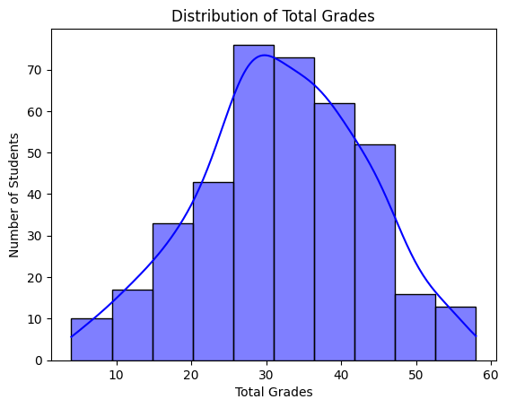

```python
# Plotting a histogram using seaborn for a more polished look
sns.histplot(df['total_grades'], bins=10, kde=True, color='blue')
plt.title('Distribution of Total Grades')
plt.xlabel('Total Grades')
plt.ylabel('Number of Students')
plt.show()
```

**Here we are calculates the total grades for each student by summing their Grade 1 (G1), Grade 2 (G2), and Grade 3 (G3) scores, and stores this total in a new column called 'total_grades'.**

**It then visualizes the distribution of these total grades using a histogram created with Seaborn. The histogram is plotted with 10 bins and includes a Kernel Density Estimate (KDE) curve to show the density of the distribution. The plot is colored blue and is accompanied by a title, and labeled x-axis and y-axis, which help in understandinthehe overall distribution of students' combined grades. The histogram provides a clear view of how the total grades are spread across the student populatn.**

# Legal Drinker :--

```
legal_drinker
False    394
True       1
Name: count, dtype: int64

There are 394 students who do not drink alcohol legally.
```

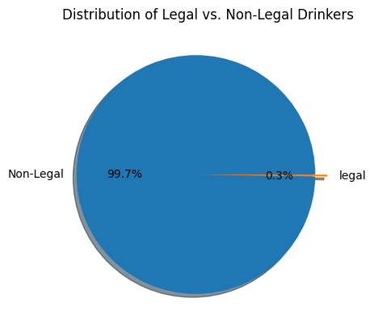

```python
legal = df.legal_drinker.value_counts()
print(legal, '\n')
print(f"There are {legal[0]} students who do not drink alcohol legally.")
plt.pie(legal, labels=["Non-Legal", "legal"], autopct='%1.1f%%', shadow=True, explode=[0.1, 0])
plt.title("Distribution of Legal vs. Non-Legal Drinkers")
plt.show()
```

**Here we can see that students based on their legal drinking status. It starts by printing the count of students who do and do not drink alcohol legally, then specifically highlights the number of students who do not drink alcohol legally. A pie chart is created to visually represent the proportions of legal versus non-legal drinkers. The chart includes percentage labels, a shadow effect for better clarity, and an explosion effect to emphasize the "Non-Legal" category. This visualization helps in understanding the proportion of students who drink alcohol legally compared to those who do not.**

# Multi_Variate Graphical Representation :---

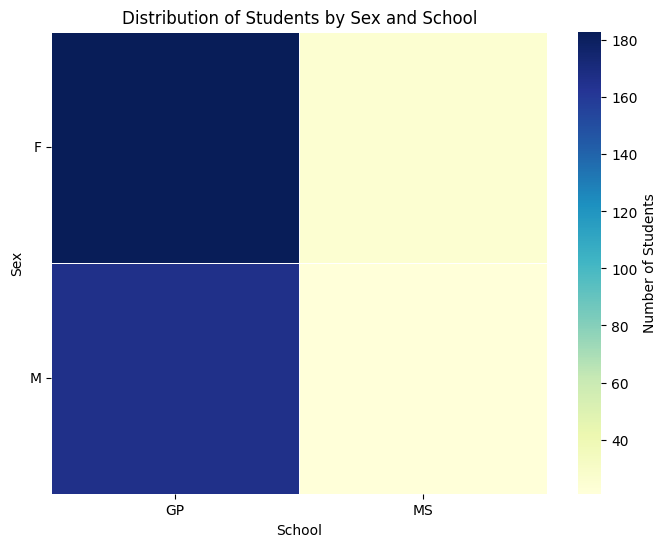

```python
#plotting school-sex
plt.figure(figsize=(8, 6))
sns.heatmap(pd.crosstab(df['sex'], df['school']), cmap="YlGnBu", cbar=True, cbar_kws={'label': 'Number of Students'}, linewidths=.5)
plt.title("Distribution of Students by Sex and School")
plt.xlabel("School")
plt.ylabel("Sex")
plt.yticks(rotation=0)
plt.show()
```

**In this basis of code we creates a heatmap to visualize the distribution of students by sex and school. It uses a cross-tabulation of the `sex` and `school` columns from the DataFrame to count the number of students in each combination of sex and school. The heatmap, colored using the "YlGnBu" palette, provides a visual representation of these counts, with a color bar indicating the number of students. The plot includes labels and titles for clarity, with y-axis labels rotated to align horizontally for better readability. This visualization helps in understanding the distribution of students across different schools and their gender.**

```python
## Numbers of Male and Female in school on the basis of perticular age
pd.crosstab(df.age, df.sex)
```

| sex age | F | M |
| --- | --- | --- |
| 15 | 38 | 44 |
| 16 | 54 | 50 |
| 17 | 58 | 40 |
| 18 | 43 | 39 |
| 19 | 14 | 10 |
| 20 | 1 | 2 |
| 21 | 0 | 1 |
| 22 | 0 | 1 |

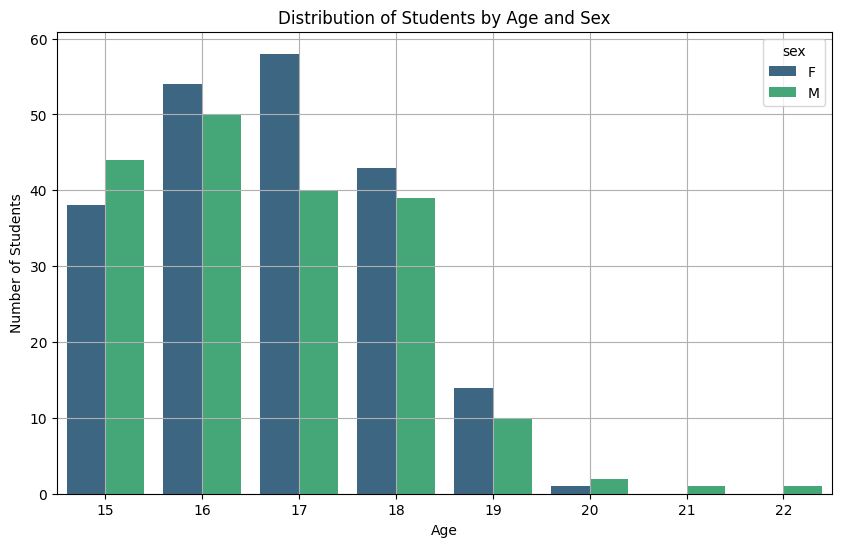

```python
crosstab_sex_age = pd.crosstab(df['sex'], df['age'])
crosstab_sex_age = crosstab_sex_age.reset_index().melt(id_vars='sex', var_name='age', value_name='Number of Students')

plt.figure(figsize=(10, 6))
sns.barplot(x='age', y='Number of Students', hue='sex', data=crosstab_sex_age, palette="viridis")
plt.title("Distribution of Students by Age and Sex")
plt.xlabel("Age")
plt.ylabel("Number of Students")
plt.xticks(rotation=0)
plt.grid()
plt.show()
```

**This code visualizes the distribution of students by age and sex using a bar plot. It begins by creating a cross-tabulation of `sex` and `age` to count the number of students in each age-sex combination. This data is then transformed into a long format using `melt` for easier plotting. A bar plot is generated where the x-axis represents age, the y-axis represents the number of students, and different colors indicate sex, using the "viridis" palette for clear differentiation. The plot includes a title, axis labels, and grid lines for better readability. This visualization allows for a clear comparison of student distribution across different ages and sexes.**

```python
#School-Address
pd.crosstab(df.school, df.address)
```

| address school | R | U |
| --- | --- | --- |
| GP | 63 | 286 |
| MS | 25 | 21 |

```python
pd.crosstab(df.sex, df.address).rename(columns={'U': 'Urban', 'R': 'Rural'})
```

| address sex | Rural | Urban |
| --- | --- | --- |
| F | 44 | 164 |
| M | 44 | 143 |

```python
# address-age
pd.crosstab(df.address, df.age)
```

| age address | 15 | 16 | 17 | 18 | 19 | 20 | 21 | 22 |
| --- | --- | --- | --- | --- | --- | --- | --- | --- |
| R | 15 | 11 | 27 | 27 | 7 | 0 | 1 | 0 |
| U | 67 | 93 | 71 | 55 | 17 | 3 | 0 | 1 |

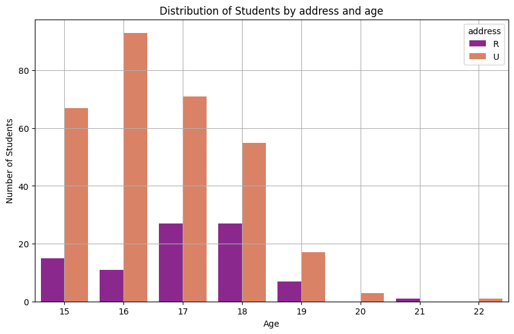

```python
# plotting: address-age
crosstab_address_age = pd.crosstab(df['address'], df['age'])
crosstab_address_age = crosstab_address_age.reset_index().melt(id_vars='address', var_name='age', value_name='Number of Students')

plt.figure(figsize=(10, 6))
sns.barplot(x='age', y='Number of Students', hue='address', data=crosstab_address_age, palette="plasma")
plt.title("Distribution of Students by address and age")
plt.xlabel("Age")
plt.ylabel("Number of Students")
plt.xticks(rotation=0)
plt.grid()
plt.show()
```

**Here we can visualizes the distribution of students based on their address and age using a bar plot. It first creates a cross-tabulation of `address` and `age` to count the number of students from different addresses for each age group. This data is then reshaped into a long format using `melt` to facilitate plotting.** **The bar plot displays the number of students on the y-axis and age on the x-axis, with different colors representing different addresses, using the "plasma" color palette for distinct differentiation. The plot includes a title, axis labels, and grid lines for enhanced readability. This visualization helps in understanding how student distribution varies by age and address.**

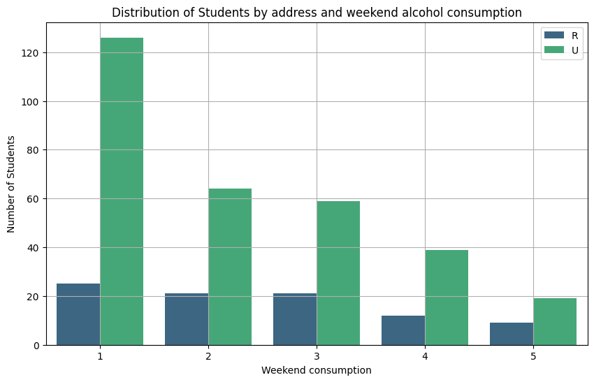

```python
#plotting weekend alcohol consumption on Rural and Urban
crosstab_address_Walc = pd.crosstab(df['address'], df['Walc'])
crosstab_address_Walc = crosstab_address_Walc.reset_index().melt(id_vars='address', var_name='Walc', value_name='Number of Students')

plt.figure(figsize=(10, 6))
sns.barplot(x='Walc', y='Number of Students', hue='address', data=crosstab_address_Walc, palette="viridis")
plt.title("Distribution of Students by address and weekend alcohol consumption")
plt.xlabel("Weekend consumption")
plt.ylabel("Number of Students")
plt.xticks(rotation=0)
plt.legend()
plt.grid()
plt.show()
```

**here we can see the distribution of students based on their address and weekend alcohol consumption using a bar plot. It first creates a cross-tabulation of `address` and `Walc` (weekend alcohol consumption) to count the number of students from different addresses for each level of weekend consumption. This data is then reshaped into a long format with `melt` for easier plotting.**

**The bar plot displays the number of students on the y-axis and weekend alcohol consumption levels on the x-axis, with different colors representing different addresses, using the "viridis" color palette for clear differentiation. The plot includes a title, axis labels, and grid lines, with a legend to identify the addresses. This visualization helps in understanding how student alcohol consumption on weekends varies by address.**

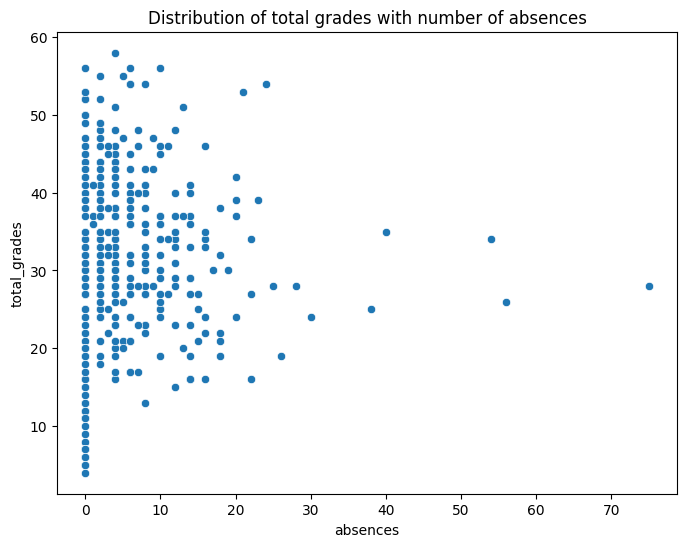

```python
plt.figure(figsize=(8, 6))
sns.scatterplot(x=df['absences'], y=df['total_grades'])
plt.title("Distribution of total grades with number of absences")
plt.show()
```

**Now we can creates a scatter plot to examine the relationship between students' total grades and their number of absences. The plot uses `absences` on the x-axis and `total_grades` on the y-axis to visualize how these two variables are related. Each point represents a student, and the plot includes a title for context. This visualization helps in identifying any potential correlation between absences and total grades.**

# 2.Part 2: Prediction and Application

# Number 1: Linear Regression

**Now it's time to use python to build some ML models to see if we can make any sort of predictions using our data. One of the main predictions the source asks us to make is final exam scores, so let's see if we can build a model that predicts those with a high degree of accuracy.**

```python
# Number 1: Linear Regression
from sklearn.linear_model import LinearRegression
model = LinearRegression()
x = np.array(df['Dalc']).reshape((-1, 1))
y = df['G1']
model.fit(x,y)
r2 = model.score(x,y)
print("Coeff of determination: " + str(round(r2,4)))
```

```
Coeff of determination: 0.0089
```

As you can see from our rough linear regression, the Dalc variable has a very weak effect on students G1 Math exam scores.

Let's try two of our strongly correlated variables as inputs for our Linear Regression Model. This time we will use two variables so we will be conducting a Multiple Linear Regression.

R2 score or the coefficient of determination is defined as the portion of the variation in one variable that is explained by one (or more) other variables in the data. So a high r2 score means that a large portion of the data's variation is explained by that variable. In Machine Learning, a good r2 score means our model is well trained and can explain our dataset well. A perfect r2 score is r2 = 1 and a very bad r2 score is r2 = 0.

```python
mmodel = LinearRegression()
x2 = df[['Medu', 'Fedu']]
x2 = np.array(x2).reshape(-1, 2)
y = df['G1']
mmodel.fit(x2, y)
mr2 = mmodel.score(x2, y)
print("Coeff of determination: " + str(round(mr2,4)))
```

```
Coeff of determination: 0.0485
```

```python
nmodel = LinearRegression()
x3 = df[['Medu', 'Fedu', 'G2', 'studytime']]
x3 = np.array(x3).reshape(-1, 4)
y = df['G1']
mmodel.fit(x3, y)
mr2 = mmodel.score(x3, y)
print("Coeff of determination: " + str(round(mr2,4)))
```

```
Coeff of determination: 0.7311
```

**Linear Regression** is a form of regression where independent variables are assessed on their ability to predict a certain target variable. In our case, we have a multiple linear regression because we have multiple independent input variables, and we have a target vector of df['G1'] \ which is the vector of student's G1 exam scores.

```python
lmodel = LinearRegression()
x4 = df[['G2', 'G3', 'Fedu', 'Medu']]
x4 = np.array(x4).reshape(-1, 4)
y = df['G1']
mmodel.fit(x4, y)
mr2 = mmodel.score(x4, y)
print("Coeff of determination: " + str(round(mr2,4)))
```

```
Coeff of determination: 0.7339
```

# Number 2: Logistic Regression

```python
# Number 2: Logistic Regression

#using same training input: G2, G3, Fedu, Medu
from sklearn.linear_model import LogisticRegression
log = LogisticRegression(solver='lbfgs', max_iter=10000).fit(x4, y)
log.score(x4, y)
```

```
0.34430379746835443
```

```python
#using solely Dalc for Logistic Regression model
x = df['Dalc']
x = np.array(x).reshape(-1,1)
y = df['G1']
log2 = LogisticRegression().fit(x, y)
log2.score(x,y)
```

```
0.13164556962025317
```

**Logistic Regression** models seem to be rather ineffective at predicting these test scores.

We can determine what model is good based on what score we initially get. HOWEVER, this score is not a metric of the actual accuracy of this model, but rather what this model can describe about the current dataset we have. If we were to take this model and apply it to the portuguese scores we would get slightly different results.

# Number 3: Support Vector Machines

```python
# Number 3: Support Vector Machines
from sklearn import svm
inp = df[['G2', 'G3', 'Fedu', 'Medu']]
out = df['G1']
svmt = svm.SVR().fit(inp,out)
svmt.score(inp, out)
```

```
0.8220122468860729
```

```python
p = df[['G2', 'G3']]
svm2 = svm.SVR().fit(p, out)
score1 = svm2.score(p, out)

q = df['G2']
w = np.array(q).reshape(-1,1)
svm3 = svm.SVR().fit(w, out)
score2 = svm3.score(w, out)

l = df['G3']
ne = np.array(l).reshape(-1,1)
svm4 = svm.SVR().fit(ne, out)
score3 = svm4.score(ne, out)
print("Support vector regression with G2 and G3 on G1: " + str(round(score1, 5)))
print("Support vector regression with JUST G2 on G1: " + str(round(score2, 5)))
print("Support vector regression with JUST G3 on G1: " + str(round(score3, 5)))
```

```
Support vector regression with G2 and G3 on G1: 0.82049
Support vector regression with JUST G2 on G1: 0.81697
Support vector regression with JUST G3 on G1: 0.78972
```

```python
# For example
# look at what the model predicts someone who received a 20/20 on G2 and G3 Exams will get:

predictThis = [[20, 20] ,[0,0], [10,10]]
ans = svm2.predict(predictThis)
ans[0:5]
```

```
array([16.32717536,  7.10050721,  9.9401869 ])
```

--^ Above is what our model predicts a student will receive based on their G2 and G3 scores